# Relación entre la exposición a la luz solar y el desarrollo de cataratas

Fuentes de datos biomédicas y web semántica

Niamey Rey, María Gómez, Claudia Tundidor

2024-12-02

```r
knitr::opts_chunk$set(echo = TRUE)
```

# **Introducción**

En este seminario se va a tratar la posible relación entre la exposición a la luz solar con el desarrollo de cataratas, una enfermedad que causa la opacidad parcial o total del cristalino. Esta enfermedad es comunmente asociada a la edad, pero trataremos su posible relación con la luz solar.

## **Objetivos**

Determinar la relación entre la exposición a la luz solar y el desarrollo de cataratas, evaluando como la radiación solar influye en la incidencia de esta enfermedad ocular

### **Objetivos específicos**

# **Materiales y métodos**

```r
library(ggplot2)
library(jsonlite)
library(dplyr)
library(pxR)
library(tidyverse)
library(tidyr)
library(sf)
library(DiagrammeR)
library(DT)
```

## **Estudios relacionados**

La relación entre la aparición de cataratas y la exposición a la luz solar ha sido objeto de estudio durante muchos años, y la evidencia científica sugiere que sí existe una relación.

Algunos que hemos encontrado: Primero, este [estudio](https://www.nei.nih.gov/about/news-and-events/news/unas-nuevas-investigaciones-exploran-como-los-rayos-uv-contribuyen-las-cataratas)

También , de la clínica oftolmatológica de Londres, este [estudio](https://www.eyecliniclondon.com/blog/sun-cause-cataracts/)

```r
#Importamos los datos con cada formato correspondiente

datos_cataratas<-read.px("DATA/INPUT/datos_cataratas.px")
datos_solar<-fromJSON("DATA/INPUT/LuzSolarProvincias.json")
```

```r
#Los transformamos a data frame y comprobamos algunas de sus filas
df_datos_solar<-as.data.frame(datos_solar)
df_datos_cataratas<-as.data.frame(datos_cataratas)
```

De las distintas enfermedades de nuestros datos, seleccionamos las de interés, que son las cataratas

```r
df_solo_cataratas <- df_datos_cataratas %>%
  filter(Enfermedades == "Cataratas")
```

```r
datatable(
  df_solo_cataratas,
  options = list(pageLength = 5)
)
```

|  | Sí.o.no | Enfermedades | Comunidad.autónoma | Sexo | value |
| --- | --- | --- | --- | --- | --- |
| 1 | Sí | Cataratas | Total Nacional | Ambos sexos | 3.73 |
| 2 | Sí | Cataratas | 01 Andalucía | Ambos sexos | 10.1 |
| 3 | Sí | Cataratas | 02 Aragón | Ambos sexos | 15.43 |
| 4 | Sí | Cataratas | 03 Asturias, Principado de | Ambos sexos | 12.07 |
| 5 | Sí | Cataratas | 04 Balears, Illes | Ambos sexos | 31.74 |
| 6 | Sí | Cataratas | 05 Canarias | Ambos sexos | 15.38 |
| 7 | Sí | Cataratas | 06 Cantabria | Ambos sexos | 20.56 |
| 8 | Sí | Cataratas | 07 Castilla y León | Ambos sexos | 12.75 |
| 9 | Sí | Cataratas | 08 Castilla - La Mancha | Ambos sexos | 14.91 |
| 10 | Sí | Cataratas | 09 Cataluña | Ambos sexos | 13.02 |

[output cut: 50 more lines]

```r
# Datos iniciales en formato data.frame
df_datos_solar <- data.frame(
  Comunidad = c('Andalucía', 'Andalucía', 'Andalucía', 'Andalucía', 'Andalucía', 'Andalucía', 'Andalucía', 'Andalucía',
                'Aragón', 'Aragón', 'Aragón', 'Asturias', 'Cantabria', 'Cataluña', 'Cataluña', 'Cataluña', 'Cataluña',
                'Castilla La-Mancha', 'Castilla La-Mancha', 'Castilla La-Mancha', 'Castilla La-Mancha', 'Castilla La-Mancha',
                'Castilla y León', 'Castilla y León', 'Castilla y León',
                'Castilla y León', 'Castilla y León', 'Castilla y León', 'Castilla y León', 'Castilla y León', 'Castilla y León',
                'Madrid', 'Comunidad Valenciana', 'Comunidad Valenciana', 'Comunidad Valenciana', 'Extremadura', 'Extremadura',
                'Galicia', 'Galicia', 'Galicia', 'Galicia', 'Islas Baleares', 'Islas Baleares', 'Islas Canarias', 'Islas Canarias',
                'Islas Canarias', 'La Rioja', 'Murcia', 'Navarra', 'País Vasco', 'País Vasco', 'País Vasco'),
  Provincia = c('Almería', 'Cádiz', 'Córdoba', 'Granada', 'Huelva', 'Jaén', 'Málaga', 'Sevilla',
                'Huesca', 'Teruel', 'Zaragoza', 'Asturias', 'Cantabria', 'Barcelona', 'Girona', 'Lleida', 'Tarragona',
                'Albacete', 'Ciudad Real', 'Cuenca', 'Guadalajara', 'Toledo', 'Ávila', 'Burgos', 'León', 'Palencia',
                'Salamanca', 'Segovia', 'Soria', 'Valladolid', 'Zamora', 'Madrid', 'Alicante', 'Castellón', 'Valencia',
                'Badajoz', 'Cáceres', 'A Coruña', 'Lugo', 'Ourense', 'Pontevedra', 'Mallorca', 'Menorca', 'Tenerife',
                'Lanzarote', 'La Palma', 'La Rioja', 'Murcia', 'Pamplona', 'Álava', 'Guipúzcoa', 'Vizcaya'),
  Horas_de_sol = c(3305, 3316, 3316, 3328, 3527, 3289, 3248, 3526, 3099, 3011, 2620, 1962, 1639, 2453, 2800, 3031, 2620,
                   3282, 3295, 2779, 2900, 2815, 3305, 2751, 2734, 2576, 3262, 3024, 2894, 3016, 2858, 2691, 3397, 3321,
                   2808, 3224, 3365, 2453, 2820, 2800, 3031, 3098, 2981, 3098, 2924, 2800, 2708, 3348, 2285, 2147, 1906, 1694),
  Hora_solar_pico = c(6.02, 6, 5.9, 5.93, 6.02, 5.82, 5.82, 5.98, 5.67, 5.11, 5.61, 3.85, 3.97, 5.4, 4.12, 5.61, 5.59,
                      5.72, 5.76, 5.57, 5.59, 5.78, 5.27, 4.98, 5.31, 5.11, 5.34, 5.02, 5.1, 5.39, 5.43, 5.74, 5.73, 5.59,
                      5.73, 5.74, 5.7, 4.3, 4.3, 4.8, 4.4, 5.3, 5.3, 5.3, 5.9, 5.9, 4.54, 5.7, 4.74, 4.2, 3.6, 3.86)
)
```

```r
datatable(df_datos_solar)
```

|  | Comunidad | Provincia | Horas_de_sol | Hora_solar_pico |
| --- | --- | --- | --- | --- |
| 1 | Andalucía | Almería | 3305 | 6.02 |
| 2 | Andalucía | Cádiz | 3316 | 6 |
| 3 | Andalucía | Córdoba | 3316 | 5.9 |
| 4 | Andalucía | Granada | 3328 | 5.93 |
| 5 | Andalucía | Huelva | 3527 | 6.02 |
| 6 | Andalucía | Jaén | 3289 | 5.82 |
| 7 | Andalucía | Málaga | 3248 | 5.82 |
| 8 | Andalucía | Sevilla | 3526 | 5.98 |
| 9 | Aragón | Huesca | 3099 | 5.67 |
| 10 | Aragón | Teruel | 3011 | 5.11 |

[output cut: 42 more lines]

Para tener un concepto mas visual antes de empezar a relacionar nuestros datos, vamos a crear un esquema relacional para explicaros con que data frames vamos a trabajar y como los vamos a unir

```r
# Crear el esquema relacional
grViz("
digraph esquema_relacional {
  graph [layout = dot, rankdir = LR, fontname = Helvetica, fontsize = 12]

  # Definición de los nodos para las tablas
  node [shape = rectangle, style = filled, fillcolor = lightblue, fontname = Helvetica]

  # Tabla Horas_de_Sol
  Horas_de_Sol [label = 'Horas_de_Sol\nComunidad (String)\nProvincia (String)\nHoras_de_sol (Numeric)\nHora_solar_pico (Numeric)']

  # Tabla Cataratas
  Cataratas [label = 'Cataratas\nComunidad.autónoma (String)\nCataratas (String)\nSexo (String)\nvalue (Numeric)']

  # Establecer que la conexion va a estar entre las comunidades
  edge [arrowhead = none, fontsize = 10]
  Horas_de_Sol -> Cataratas [label = 'Comunidad', color = grey, style = dashed]

  # Añadir colores y detalles
  subgraph cluster_1 {
    label = 'Datos de la tabla Horas_de_Sol'
    style=dotted
    color=blue
    Horas_de_Sol
  }

  subgraph cluster_2 {
    label = 'Datos de la tabla Cataratas'
    style=dotted
    color=red
    Cataratas
  }
}
")
```

[interactive chart not shown]

Antes de empezar a manejar los datos, crearemos un mapa para ver reflejadas tanto las cataratas como las horas de sol por regiones, en mapas distintivos para cada una de ellas

```r
mapa_espana <- st_read("./DATA/INPUT/ESP_adm1.shp")
# Revisar los nombres de las columnas
colnames(mapa_espana)
```

```
##  [1] "GID_4"     "GID_0"     "COUNTRY"   "GID_1"     "NAME_1"    "GID_2"
##  [7] "NAME_2"    "GID_3"     "NAME_3"    "NAME_4"    "VARNAME_4" "TYPE_4"
## [13] "ENGTYPE_4" "CC_4"      "geometry"
```

```r
# Revisar las regiones del mapa para ver cómo se llaman
# Ver los valores únicos de la columna NAME_1 (Comunidades Autónomas)
unique(mapa_espana$NAME_1)
```

```
##  [1] "Andalucía"                  "Aragón"
##  [3] "Cantabria"                  "Castilla-La Mancha"
##  [5] "Castilla y León"            "Cataluña"
##  [7] "Ceuta y Melilla"            "Comunidad de Madrid"
##  [9] "Comunidad Foral de Navarra" "Comunidad Valenciana"
## [11] "Extremadura"                "Galicia"
## [13] "Islas Baleares"             "Islas Canarias"
## [15] "La Rioja"                   "País Vasco"
## [17] "Principado de Asturias"     "Región de Murcia"
```

```r
# Realizamos la unión de los datos
mapa_espana_completo <- mapa_espana %>%
  left_join(df_datos_solar, by = c("NAME_1" = "Comunidad"))
```

Crear el mapa con las horas de sol

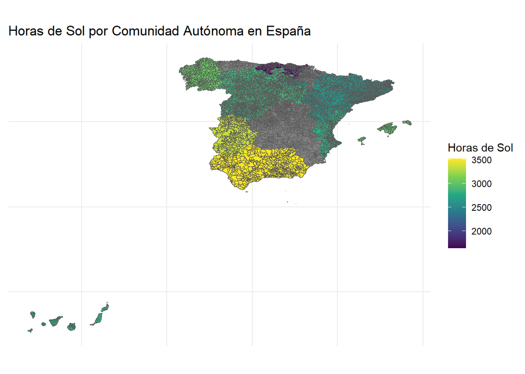

```r
ggplot(data = mapa_espana_completo) +
  geom_sf(aes(fill = `Horas_de_sol`)) +
  scale_fill_viridis_c() +  # Usar una paleta de colores continua
  theme_minimal() +
  labs(title = "Horas de Sol por Comunidad Autónoma en España",
       fill = "Horas de Sol") +
  theme(axis.text = element_blank(),
        axis.title = element_blank())
```

Ahora veremos las cataratas por comunidad

```r
#Cambiamos los nombres de las comunidades para que coincidan y poder hacer un join
df_solo_cataratas <- df_solo_cataratas %>%
  mutate(
    Comunidad.autónoma = case_when(
      Comunidad.autónoma == "01 Andalucía" ~ "Andalucía",
      Comunidad.autónoma == "02 Aragón" ~ "Aragón",
      Comunidad.autónoma == "03 Asturias, Principado de" ~ "Asturias",
      Comunidad.autónoma == "04 Balears, Illes" ~ "Islas Baleares",
      Comunidad.autónoma == "05 Canarias" ~ "Islas Canarias",
      Comunidad.autónoma == "06 Cantabria" ~ "Cantabria",
      Comunidad.autónoma == "07 Castilla y León" ~ "Castilla y León",
      Comunidad.autónoma == "08 Castilla - La Mancha" ~ "Castilla La-Mancha",
      Comunidad.autónoma == "09 Cataluña" ~ "Cataluña",
      Comunidad.autónoma == "10 Comunitat Valenciana" ~ "Comunidad Valenciana",
      Comunidad.autónoma == "11 Extremadura" ~ "Extremadura",
      Comunidad.autónoma == "12 Galicia" ~ "Galicia",
      Comunidad.autónoma == "13 Madrid, Comunidad de" ~ "Madrid",
      Comunidad.autónoma == "14 Murcia, Región de" ~ "Murcia",
      Comunidad.autónoma == "15 Navarra, Comunidad Foral de" ~ "Navarra",
      Comunidad.autónoma == "16 País Vasco" ~ "País Vasco",
      Comunidad.autónoma == "17 Rioja, La" ~ "La Rioja",
      Comunidad.autónoma == "18 Ceuta" ~ "Ceuta",
      Comunidad.autónoma == "19 Melilla" ~ "Melilla",
      Comunidad.autónoma == "Total Nacional" ~ "Total Nacional",
      TRUE ~ Comunidad.autónoma  # Dejar sin cambios si no coincide
    )
  )%>%
  filter(!Comunidad.autónoma %in% c("Total Nacional"))
```

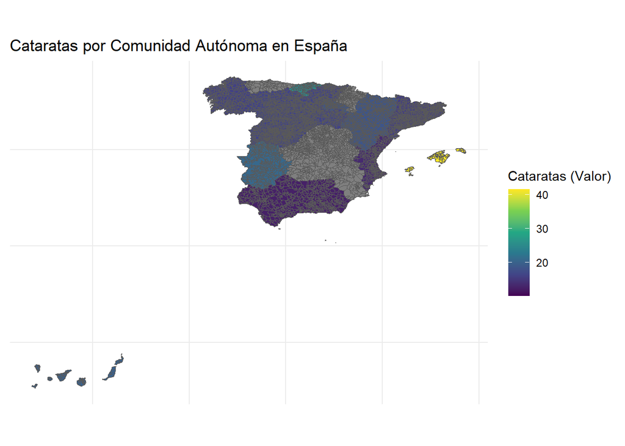

```r
mapa_espana_completo <- mapa_espana %>%
  left_join(df_solo_cataratas, by = c("NAME_1" = "Comunidad.autónoma"))
# Crear el mapa con las cataratas

df_solo_cataratas$Comunidad.autónoma <- trimws(df_solo_cataratas$Comunidad.autónoma)
mapa_espana_completo$NAME_1 <- trimws(mapa_espana_completo$NAME_1)  # Eliminar espacios extra

mapa_espana_completo <- mapa_espana_completo %>%
  left_join(df_solo_cataratas, by = c("NAME_1" = "Comunidad.autónoma"))
ggplot(data = mapa_espana_completo) +
  geom_sf(aes(fill = value.y)) +
  scale_fill_viridis_c() +
  theme_minimal() +
  labs(title = "Cataratas por Comunidad Autónoma en España",
       fill = "Cataratas (Valor)") +
  theme(axis.text = element_blank(),
        axis.title = element_blank())
```

```r
# Calcular la media de Horas de Sol por Comunidad
media_horas_sol <- tapply(df_datos_solar$Horas_de_sol, df_datos_solar$Comunidad, mean)

# Mostrar el resultado
print(media_horas_sol)
```

```
##            Andalucía               Aragón             Asturias
##             3356.875             2910.000             1962.000
##            Cantabria   Castilla La-Mancha      Castilla y León
##             1639.000             3014.200             2935.556
##             Cataluña Comunidad Valenciana          Extremadura
##             2726.000             3175.333             3294.500
##              Galicia       Islas Baleares       Islas Canarias
##             2776.000             3039.500             2940.667
##             La Rioja               Madrid               Murcia
##             2708.000             2691.000             3348.000
##              Navarra           País Vasco
##             2285.000             1915.667
```

```r
#Lo transformamos a dataframe
df_media_horas_sol <- as.data.frame(media_horas_sol)
```

A continuación, proporcionamos una alternativa a la creación manual del data frame.

Primero, pivotamos los datos a formato largo

[output not shown]

print(df_sol_largo)

Separar ‘Comunidad.Provincia’ en dos columnas con el comando separate

[output not shown]

Verificamos el dataframe después de la transformación

print(head(df_sol_largo))

datatable(df_sol_largo)

Calculamos la media de las horas de sol por comunidad, para ello importamos una función que hemos realizado

source(“FUNCTIONS/CalcularMediaSol.R”)

calcular_media_horas_sol(df_sol_largo)

Mostramos el resultado final

print(media_horas_sol)

```r
#Creamos categorías para clasificar las horas de sol por comunidad y transformamos las categorías en factores
df_sol_clasificado <- df_media_horas_sol %>%
  mutate(
    clasificacion = factor(case_when(
      media_horas_sol < 2500 ~ "Bajo",
      media_horas_sol >= 2500 & media_horas_sol < 3000 ~ "Medio",
      media_horas_sol > 3000 ~ "Alto"
    )
  )
)
```

```r
#Vamos a ponerle nombre a la columna correspondiente a las comunidades
# Creamos una nueva columna "comunidad" con los nombres de las filas
df_sol_clasificado$Comunidad <- rownames(df_sol_clasificado)

# Reordenamos las columnas para que "comunidad" sea la primera
df_sol_clasificado <- df_sol_clasificado[, c("Comunidad", "media_horas_sol", "clasificacion")]
```

```r
df_sol_definitivo <- df_sol_clasificado %>%
  select(Comunidad,media_horas_sol,clasificacion)
```

```r
#Unimos las dos tablas mediante la columna de la Comunidad Autónoma
df_final <- df_solo_cataratas %>%
  left_join(df_sol_definitivo, by = c("Comunidad.autónoma"="Comunidad")) #Realizamos un join sin necesidad de cambiar el nombre del atributo en una de las tablas
```

```r
#Ordenamos de mayor a menor en función de las horas de sol
df_final_sol<-df_final%>%
  group_by(Comunidad.autónoma)%>%
  select(media_horas_sol,clasificacion,Sexo,value)%>%
  arrange(desc(media_horas_sol))
datatable(df_final_sol)
```

|  | Comunidad.autónoma | media_horas_sol | clasificacion | Sexo | value |
| --- | --- | --- | --- | --- | --- |
| 1 | Andalucía | 3356.875 | Alto | Ambos sexos | 10.1 |
| 2 | Andalucía | 3356.875 | Alto | Hombres | 15.85 |
| 3 | Andalucía | 3356.875 | Alto | Mujeres | 12.49 |
| 4 | Murcia | 3348 | Alto | Ambos sexos | 13.83 |
| 5 | Murcia | 3348 | Alto | Hombres | 20.89 |
| 6 | Murcia | 3348 | Alto | Mujeres | 17.9 |
| 7 | Extremadura | 3294.5 | Alto | Ambos sexos | 18.91 |
| 8 | Extremadura | 3294.5 | Alto | Hombres | 31.53 |
| 9 | Extremadura | 3294.5 | Alto | Mujeres | 20.69 |
| 10 | Comunidad Valenciana | 3175.333333333333 | Alto | Ambos sexos | 11.11 |

[output cut: 47 more lines]

```r
#Ordenamos de mayor a menor en función de las cataratas
df_final_cataratas<-df_final%>%
  group_by(Comunidad.autónoma)%>%
  select(media_horas_sol,clasificacion,Sexo,value)%>%
  arrange(desc(value))
datatable(df_final_cataratas)
```

|  | Comunidad.autónoma | media_horas_sol | clasificacion | Sexo | value |
| --- | --- | --- | --- | --- | --- |
| 1 | Melilla |  |  | Hombres | 75.22 |
| 2 | Melilla |  |  | Mujeres | 64.02 |
| 3 | Ceuta |  |  | Mujeres | 51.49 |
| 4 | Ceuta |  |  | Hombres | 51.37 |
| 5 | Melilla |  |  | Ambos sexos | 48.79 |
| 6 | Islas Baleares | 3039.5 | Alto | Mujeres | 41.65 |
| 7 | Islas Baleares | 3039.5 | Alto | Hombres | 41.17 |
| 8 | Cantabria | 1639 | Bajo | Hombres | 37.98 |
| 9 | Ceuta |  |  | Ambos sexos | 36.31 |
| 10 | Navarra | 2285 | Bajo | Hombres | 34.42 |

[output cut: 47 more lines]

```r
#Realizamos el estudio en función de los sexos
df_mujeres<-df_final%>%
  group_by(Comunidad.autónoma)%>%
  select(media_horas_sol,clasificacion,Sexo,value)%>%
  filter(Sexo=="Mujeres")%>%
  arrange(desc(media_horas_sol))
datatable(df_mujeres)
```

|  | Comunidad.autónoma | media_horas_sol | clasificacion | Sexo | value |
| --- | --- | --- | --- | --- | --- |
| 1 | Andalucía | 3356.875 | Alto | Mujeres | 12.49 |
| 2 | Murcia | 3348 | Alto | Mujeres | 17.9 |
| 3 | Extremadura | 3294.5 | Alto | Mujeres | 20.69 |
| 4 | Comunidad Valenciana | 3175.333333333333 | Alto | Mujeres | 13.45 |
| 5 | Islas Baleares | 3039.5 | Alto | Mujeres | 41.65 |
| 6 | Castilla La-Mancha | 3014.2 | Alto | Mujeres | 19.19 |
| 7 | Islas Canarias | 2940.666666666667 | Medio | Mujeres | 19.91 |
| 8 | Castilla y León | 2935.555555555556 | Medio | Mujeres | 16.25 |
| 9 | Aragón | 2910 | Medio | Mujeres | 18.38 |
| 10 | Galicia | 2776 | Medio | Mujeres | 16.03 |

[output cut: 9 more lines]

```r
df_hombres<- df_final%>%
  group_by(Comunidad.autónoma)%>%
  select(media_horas_sol,clasificacion,Sexo,value)%>%
  filter(Sexo=="Hombres")%>%
  arrange(desc(media_horas_sol))
datatable(df_hombres)
```

|  | Comunidad.autónoma | media_horas_sol | clasificacion | Sexo | value |
| --- | --- | --- | --- | --- | --- |
| 1 | Andalucía | 3356.875 | Alto | Hombres | 15.85 |
| 2 | Murcia | 3348 | Alto | Hombres | 20.89 |
| 3 | Extremadura | 3294.5 | Alto | Hombres | 31.53 |
| 4 | Comunidad Valenciana | 3175.333333333333 | Alto | Hombres | 19.13 |
| 5 | Islas Baleares | 3039.5 | Alto | Hombres | 41.17 |
| 6 | Castilla La-Mancha | 3014.2 | Alto | Hombres | 23.54 |
| 7 | Islas Canarias | 2940.666666666667 | Medio | Hombres | 24.88 |
| 8 | Castilla y León | 2935.555555555556 | Medio | Hombres | 21.71 |
| 9 | Aragón | 2910 | Medio | Hombres | 23.76 |
| 10 | Galicia | 2776 | Medio | Hombres | 18.83 |

[output cut: 9 more lines]

Incluimos un df para ambos sexos, pero haremos los estudios separando hombres y mujeres

```r
df_ambos<-df_final%>%
  group_by(Comunidad.autónoma)%>%
  select(media_horas_sol,clasificacion,Sexo,value)%>%
  filter(Sexo=="Ambos sexos")%>%
  arrange(desc(media_horas_sol))
datatable(df_ambos)
```

|  | Comunidad.autónoma | media_horas_sol | clasificacion | Sexo | value |
| --- | --- | --- | --- | --- | --- |
| 1 | Andalucía | 3356.875 | Alto | Ambos sexos | 10.1 |
| 2 | Murcia | 3348 | Alto | Ambos sexos | 13.83 |
| 3 | Extremadura | 3294.5 | Alto | Ambos sexos | 18.91 |
| 4 | Comunidad Valenciana | 3175.333333333333 | Alto | Ambos sexos | 11.11 |
| 5 | Islas Baleares | 3039.5 | Alto | Ambos sexos | 31.74 |
| 6 | Castilla La-Mancha | 3014.2 | Alto | Ambos sexos | 14.91 |
| 7 | Islas Canarias | 2940.666666666667 | Medio | Ambos sexos | 15.38 |
| 8 | Castilla y León | 2935.555555555556 | Medio | Ambos sexos | 12.75 |
| 9 | Aragón | 2910 | Medio | Ambos sexos | 15.43 |
| 10 | Galicia | 2776 | Medio | Ambos sexos | 11.72 |

[output cut: 9 more lines]

Graficamos: Empezamos por el grafico de cataratas-horas de sol en las comunidades, solo para mujeres:

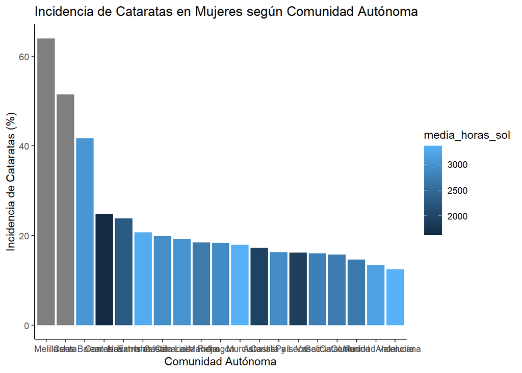

```r
ggplot(data = df_mujeres, aes(x = reorder(Comunidad.autónoma,-value), y = value) ) +
  geom_bar(stat = "identity", aes(fill = media_horas_sol) ) +
  labs(x = "Comunidad Autónoma",
       y = "Incidencia de Cataratas (%)",
       title = "Incidencia de Cataratas en Mujeres según Comunidad Autónoma",
       colour = "Horas de Sol") +
  theme_classic()
```